# **Lab 3.2 - Developing a Custom Image Classification Model**

# **Learning Objectives**

After completing this project, you will be able to:

- Understand the basics of machine learning by building and training an image classification model using Teachable Machine.
- Apply AI tools to solve real-world library tasks, such as identifying book genres or recognizing commonly used items.
- Learn how to collect, organize, and label image data to create effective training sets for custom model development.
- Test, evaluate, and optionally deploy your model for practical use in web-based or real-time applications.

### Step 1 - Open Teachable Machine and Start a New Project

1. Click [this link](https://teachablemachine.withgoogle.com) to open Teachable Machine.
2. Then click the "Get Started"
3. Select "Image Project" then choose "Standard Image Model."

### Step 2 - Define Your Classes

Now we have to define our classes for our project. By default there are 2 classes called Class 1 and Class 2. Press the ✏️ button to rename them to "Children's Books" and "Young Adult Books." It should look like this now:

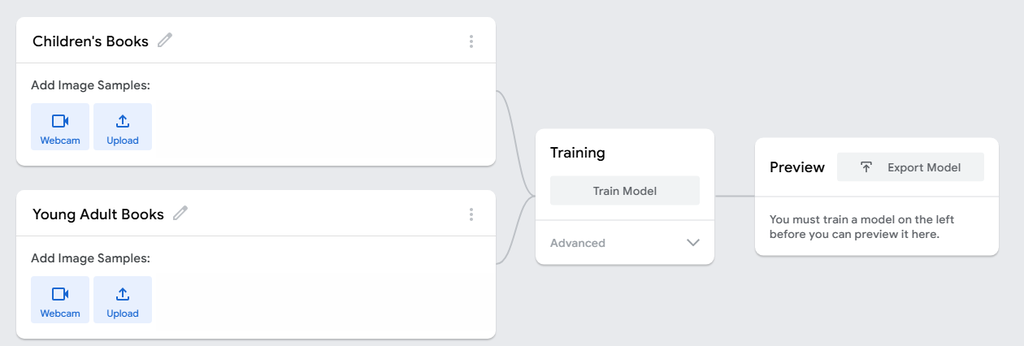

### Step 4 - Unzip the Data

The file that you downloaded is actually a zip file - which means it has been compressend. To unzip it, open File Explorer and go to the folder where the zip file is. Then select the zip, click "Extract all."

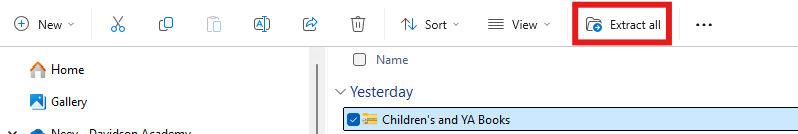

Then a dialog box will pop up, and simply select "Extract." This will download all the files to your computer.

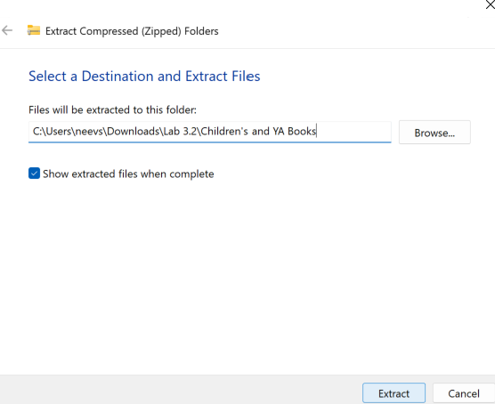

### Step 5 - Upload the Training Data

Now that the files are on your computer, we can upload them into Teachable Machine! Go back to that tab and select "Upload" under the "Children's Books" class. Then select "Choose images from your files" which will allow you to select the Children's Books images.

Navigate to the folder where the images are saved and open the Children's Books folder. Use the shortcut "Ctrl+A" to highlight all the files and click "Open" at the bottom.

After a few seconds, the images should be uploaded.

Repeat this step for the "Young Adult Books" class and make sure to upload the images from the Young Adult Books folder.

### Step 6 - Train your model

The hard part is done! At this point, the button that says "Train Model" should be blue. Click that button to start the training process - which should only take a couple minutes.

### Step 7 - Test it out!

After the model is finished training, it should be ready for you to test! In the preview box, there will be an option to use your webcam to scan a book. However, we will upload a file by clicking "File" in the dropdown.

[figure not shown]

Then you can upload a file from the test images (which are in the Testing Images folder in the zip file you downloaded) and see how it does!

Optional: Search up a children's/young adult book you know on Google, then go to Images and download an image of the cover. Then upload it into your model and see how well it performs!

### Step 8 - Share it!

To share your model, click the "Export Model" button next to Preview. Don't worry about the code or the Tensorflow tabs, and simply click "Upload my model" and it will generate a shareable link!

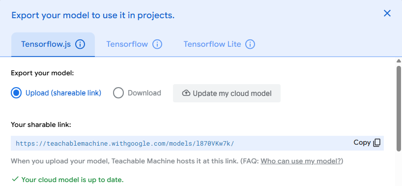